# Regression Analysis

Group 4

3/7/2021

## Hypothesis 1

Our group decided to test out 2 hypothesis for this project. This is the document for our first hypothesis.

## Read input files from github

Get the link which has the merged data from github, then read the csv file and save it as a dataframe in R for analysis.

```r
link='https://raw.githubusercontent.com/Public-Policy-COVID/students_merge/main/Merged_data.csv'
myFile=url(link)
fromPy=read.csv(file = myFile)
```

# Summary results of merged data

In order to understand our merged dataset, we need to know some of the basic statistical summary for it.

```r
summary(fromPy)
```

```
##  Number_of_beds    Number_of_hospitals   Location         Urban_Rural_Code
##  Min.   :    0.0   Min.   :  0         Length:133         Length:133
##  1st Qu.:   25.0   1st Qu.:  1         Class :character   Class :character
##  Median :  131.0   Median :  2         Mode  :character   Mode  :character
##  Mean   :  885.4   Mean   :  5
##  3rd Qu.:  553.0   3rd Qu.:  4
##  Max.   :26672.0   Max.   :112
##   Deaths_COVID   Deaths_total       never             rarely
##  Min.   :   0   Min.   :    0   Min.   :0.00100   Min.   :0.00000
##  1st Qu.:   0   1st Qu.:    0   1st Qu.:0.01600   1st Qu.:0.01400
##  Median :  22   Median :  637   Median :0.02600   Median :0.02800
##  Mean   : 206   Mean   : 2896   Mean   :0.03513   Mean   :0.03806
##  3rd Qu.: 128   3rd Qu.: 2537   3rd Qu.:0.04500   3rd Qu.:0.05600
##  Max.   :8034   Max.   :75463   Max.   :0.14000   Max.   :0.20600
##    sometimes         frequently         always         mask_score
##  Min.   :0.00400   Min.   :0.0580   Min.   :0.3050   Min.   :2.470
##  1st Qu.:0.04800   1st Qu.:0.1410   1st Qu.:0.6160   1st Qu.:3.301
##  Median :0.06900   Median :0.1680   Median :0.6810   Median :3.464
##  Mean   :0.07167   Mean   :0.1736   Mean   :0.6814   Mean   :3.428
##  3rd Qu.:0.09100   3rd Qu.:0.2040   3rd Qu.:0.7540   3rd Qu.:3.591
##  Max.   :0.21300   Max.   :0.3320   Max.   :0.8890   Max.   :3.822
##  total_population   white_total_pct black_total_pct  aian_total_pct
##  Min.   :    1129   Min.   :49.28   Min.   : 0.000   Min.   : 0.590
##  1st Qu.:   24658   1st Qu.:82.16   1st Qu.: 0.770   1st Qu.: 1.430
##  Median :   79481   Median :88.64   Median : 1.260   Median : 2.010
##  Mean   :  385537   Mean   :85.50   Mean   : 2.318   Mean   : 2.985
##  3rd Qu.:  283111   3rd Qu.:91.84   3rd Qu.: 2.620   3rd Qu.: 3.070
##  Max.   :10039107   Max.   :96.13   Max.   :14.770   Max.   :25.690
##  asian_total_pct  nhopi_total_pct  multiracial_total_pct
##  Min.   : 0.500   Min.   :0.0000   Min.   :1.200
##  1st Qu.: 1.210   1st Qu.:0.2100   1st Qu.:3.160
##  Median : 1.870   Median :0.2800   Median :3.720
##  Mean   : 4.961   Mean   :0.3838   Mean   :3.856
##  3rd Qu.: 5.840   3rd Qu.:0.4500   3rd Qu.:4.440
##  Max.   :39.020   Max.   :1.7100   Max.   :7.800
```

## Test hypothesis

We use regression when we have a continuous outcome or dependent variable, and a set of independent variables which can be of different types.

Run a regression to test the hypothesis that as number of hospitals, number of hospital beds and total_population increases, covid deaths increase and as mask score increases covid deaths decrease.

We use the glm function in R to run a linear regression.

```r
hypo1 = formula(Deaths_COVID~ Number_of_hospitals+Number_of_beds+mask_score+total_population)
gauss1=glm(hypo1,
           data = fromPy,
           family = 'gaussian')
```

See the results of our linear regression.

```r
summary(gauss1)
```

```
##
## Call:
## glm(formula = hypo1, family = "gaussian", data = fromPy)
##
## Deviance Residuals:
##     Min       1Q   Median       3Q      Max
## -670.42   -18.47    24.92    62.44   648.61
##
## Coefficients:
##                       Estimate Std. Error t value Pr(>|t|)
## (Intercept)          4.873e+02  2.254e+02   2.161 0.032530 *
## Number_of_hospitals  2.234e+01  9.516e+00   2.348 0.020429 *
## Number_of_beds       7.056e-02  3.975e-02   1.775 0.078268 .
## mask_score          -1.679e+02  6.596e+01  -2.545 0.012106 *
## total_population     3.114e-04  9.110e-05   3.418 0.000845 ***
## ---
## Signif. codes:  0 '***' 0.001 '**' 0.01 '*' 0.05 '.' 0.1 ' ' 1
##
## (Dispersion parameter for gaussian family taken to be 26565.43)
##
##     Null deviance: 76635132  on 132  degrees of freedom
## Residual deviance:  3400375  on 128  degrees of freedom
## AIC: 1739.3
##
## Number of Fisher Scoring iterations: 2
```

Get R squared of the model. R-squared is the percentage of the dependent variable variation that a linear model explains. R-squared helps us decide how effective this model is and compare it with other hypothesis as well.

```r
library(rsq)
rsq(gauss1,adj=T)
```

```
## [1] 0.9542424
```

## Summary plots

In order to visualize the results of our hypothesis and the dependent variables, we use different summary plots.

Plotting the regression coefficients.

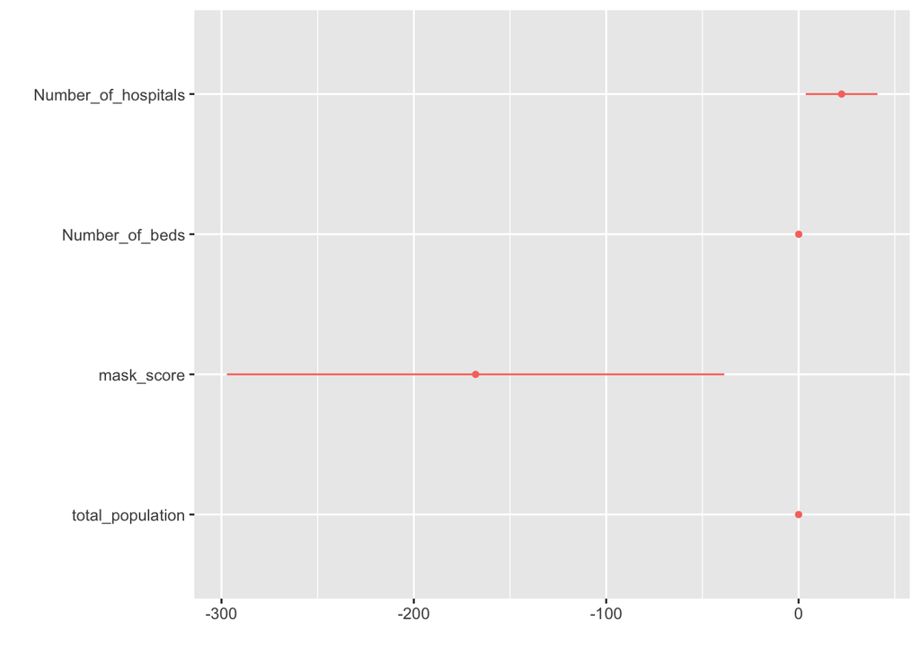

```r
# Summary plots
library(dotwhisker)
dwplot(gauss1,by_2sd = F)
```

Margin plot for number of hospitals variable.

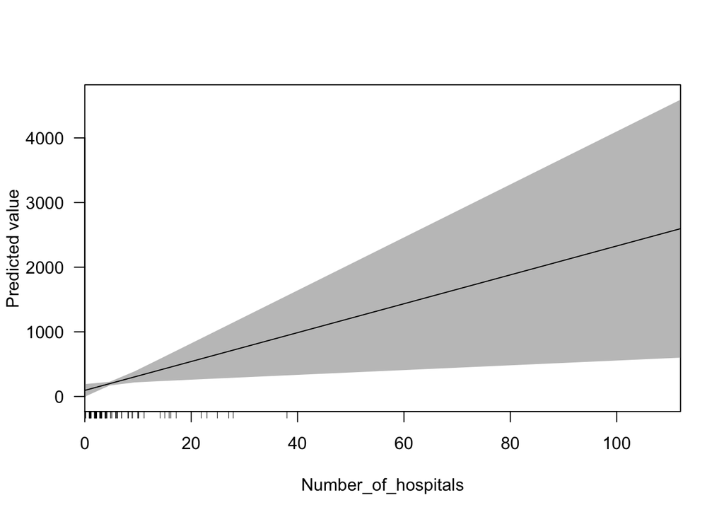

```r
library(margins)
cplot(gauss1,'Number_of_hospitals')
```

Margin plot for number of beds variable.

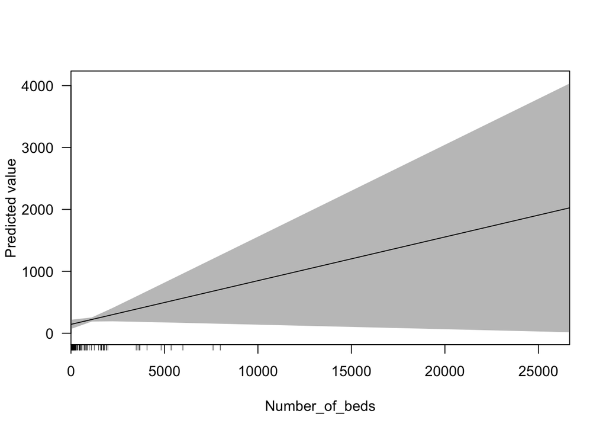

```r
cplot(gauss1,'Number_of_beds')
```

Margin plot for mask score variable.

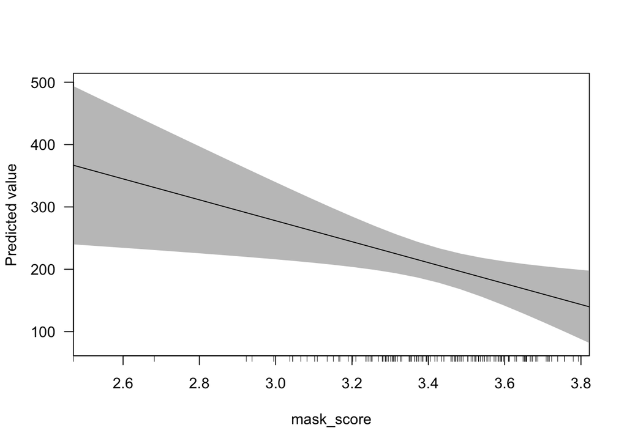

```r
cplot(gauss1,'mask_score')
```

Margin plot for total population variable.

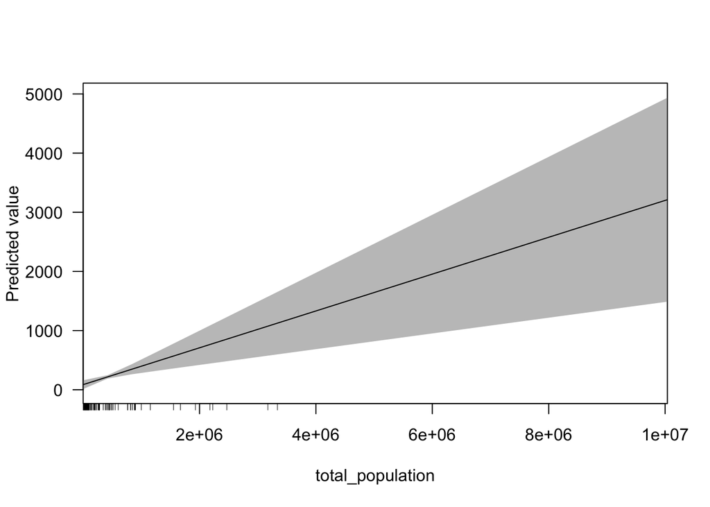

```r
cplot(gauss1,'total_population')
```

Plot interaction between variables.

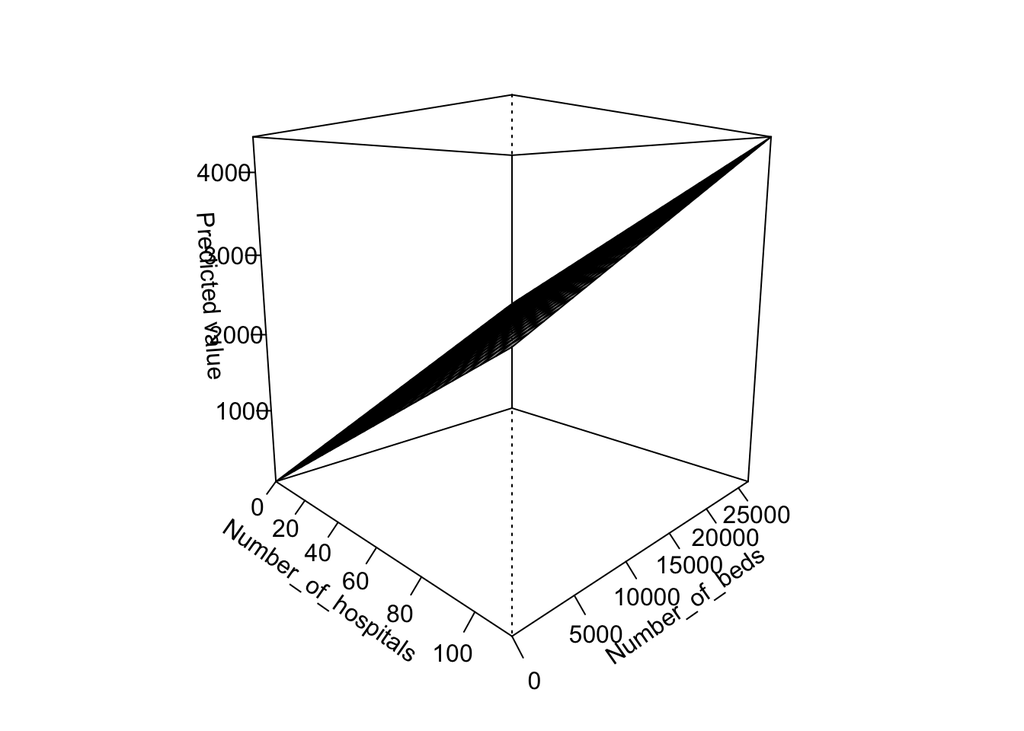

```r
persp(gauss1)
```